# Projet Info-Stat UE MI0A403T

Ahouangassi franck, Alichebana Mohammed , Moueley Mboumi

```r
knitr::opts_chunk$set(echo = TRUE, message = FALSE)
```

# 1 Base de données

## 1.1 Construction de la base de données

*Phase 1: Analyse des besoins*

Avant toute construction, nous avons effectué une **analyse fonctionnelle** afin de bien comprendre les besoins métier à partir des fichiers données. Cette phase a permis d’identifier les **entités principales** (par exemple :Incendie, Meteo, Geo) et leurs relations.

*Phase 2: Modélisation conceptuelle (MCD)*

À partir des besoins, nous avons conçu un **Modèle Conceptuel de Données (MCD)** avec à l’aide de l’outil lucidchart. Ce modèle fait apparaître :

- Les entités avec leurs attributs (ex : `Geo (code_INSEE, latitude, longitude, altitude_med)`)
- Les relations entre les entités (ex : un incendie n’a qu’une seul météo…)

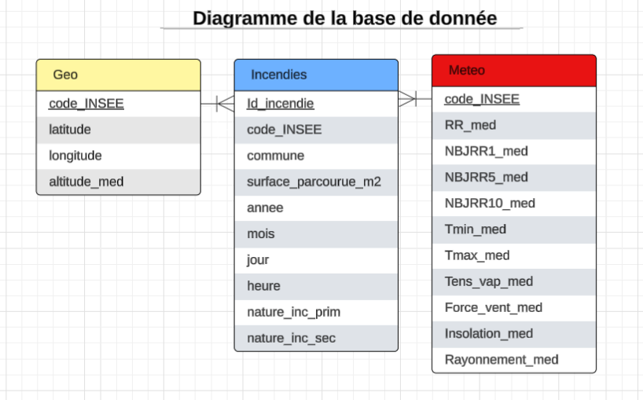

*Phase 3: Modélisation logique (MLD)*

Nous avons ensuite transformé le MCD en **Modèle Logique de Données (MLD)**. Chaque entité devient une **table**, et chaque relation est traduite par :

- une table associative en cas de relation plusieurs-à-plusieurs.

Exemple :

```sql
CREATE TABLE Incendies (
    id_incendie INTEGER PRIMARY KEY AUTOINCREMENT,
    code_INSEE VARCHAR(55),
    commune VARCHAR(55) NOT NULL,
    surface_parcourue_m2 INT NOT NULL CHECK (surface_parcourue_m2 > 0),
    annee INT NOT NULL,
    mois TEXT NOT NULL CHECK (mois IN ('Jan', 'Feb', 'Mar', 'Apr', 'May', 'Jun',
                                        'Jul', 'Aug', 'Sep', 'Oct', 'Nov', 'Dec')),
    jour INT NOT NULL CHECK (jour BETWEEN 1 AND 31),
    heure INT NOTNOT NULL CHECK (heure BETWEEN 0 AND 23),
    nature_inc_prim TEXT DEFAULT NULL CHECK (nature_inc_prim IN
                                              ('Accidentelle', 'Involontaire',
                                               'Malveillance', 'Naturelle')),
    nature_inc_sec TEXT DEFAULT NULL,
    CONSTRAINT CHK_surface CHECK (surface_parcourue_m2 > 0)
);
```

*Phase 4: Modélisation physique (MPD)*

-Les types de données (ex : `VARCHAR`, `DATE`, `INT`)

-Les contraintes d’intégrité (ex : `NOT NULL`, `PRIMARY KEY`, `CHECK`)

*Phase 5: Tests et alimentation*

Après la création des tables, nous avons réalisé des tests d’intégrité et inséré des données fictives ou réelles pour valider le fonctionnement des relations et des contraintes pour finalement insérer les données préalablement soustraites des fichiers csv.

## 1.2 Extractions de tables depuis la base de données

*Phase 1: extraction des données csv*

Ce bloc de code permet de **lire un fichier CSV** (donnees_incendies.csv) et de **stocker chaque ligne sous forme de dictionnaire** Python dans une liste appelée resultat_incendie.

On utilise le module csv.DictReader préalablement importé qui lit automatiquement les en-têtes du fichier comme **clés** des dictionnaires.

Cela facilite le traitement des données par la suite, en accédant directement aux valeurs par nom de colonne (ex : `row["code_INSEE"]`).

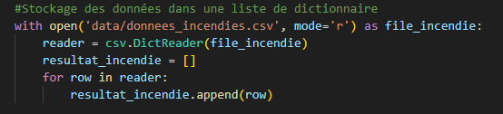

Remarque: cette opération est répétée pour chaque dossier csv.

*Phase 2: Création et connexion de la BD sur python*

La fonction connect(nom_base) vérifie si la base de données SQLite existe.

-**Si elle n’existe pas**, elle est créée, ainsi que les quatre tables : Incendies, Meteo et Geo avec leurs colonnes et clés primaires.

-**Sinon**, la fonction affiche les tables déjà présentes dans la base.

La fonction retourne aussi deux objets qui nous seront utile plus tard:

-**db**: la connexion à la base (utilise pour les commits, les fermetures et rollbacks) -**curs**: le curseur permettant d’exécuter des requêtes SQL

Cette méthode garantit que la structure de la base est en place avant d’y insérer des données, nous allons donc l’utiliser à chaque fois que l’on va se connecter à la base.

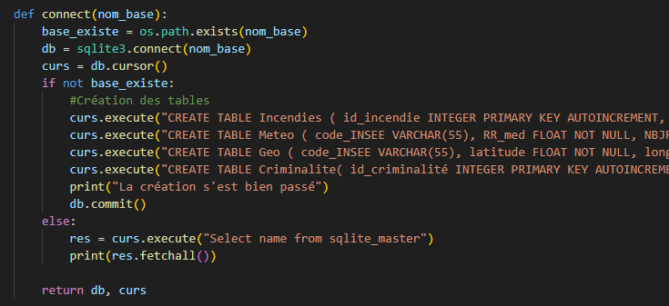

*Phase 3: Insertion des données dans la base*

La fonction ajouter_incendies() permet **d’insérer une liste de données dans la table Incendies**, il prend en paramètre la connexion à la base ‘bd’, ‘curs’ pour pouvoir exécuter les requêtes et enfin un dictionnaire ‘data’ contenant toutes les données à insérer.

-Pour chaque ligne du paramètre data, un INSERT est exécuté avec les valeurs extraites du dictionnaire (code_INSEE, commune, surface_parcourue_m2, etc.).

-En cas de succès, les données sont **validées avec commit()** et un message s’affiche.

-En cas d’erreur, la fonction affiche **l’exception**, la **ligne concernée** et annule l’opération avec *rollback()* pour **éviter d’insérer des données corrompues**.

Cette méthode garantit une insertion fiable et contrôlée des données incendies.

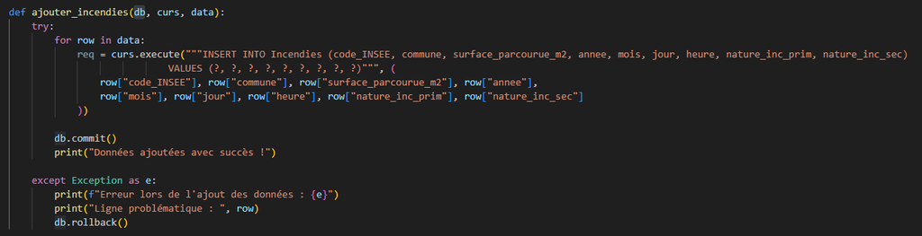

Remarque: La structure de cette méthode est utilisée sur les autres tables de la même manière. Au lieu de créer une méthode pour insérer toutes les données d’une seule traite, il est plus intéressant de faire comme ceci pour pouvoir identifier plus facilement un problème s’ il y a.

*Phase 4: Affichage des données brut*

La fonction *afficher_incendies(curs)* permet **d’afficher toutes les lignes** de la table *Incendies* de manière lisible.

-Elle commence par afficher une **ligne d’en-tête** pour faciliter la lecture des données.

-Elle exécute ensuite une requête SELECT * **pour parcourir tous les enregistrements**, et les affiche ligne par ligne dans un format structuré.

-En cas d’erreur, un message détaillé est affiché grâce à la gestion d’exception *try/except*.

Cette fonction est utile pour **vérifier visuellement** que les données ont bien été insérées dans la base.

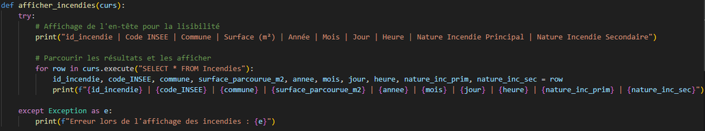

Remarque: nous n’avons pas besoin de la connexion à la base (‘bd’) car nous ne faisons qu’afficher les données et enfin cette méthode est aussi la même pour les autres tables.

*Phase 5: Export des résultats SQL vers un fichier CSV*

La fonction `writeCsv(curs, req)` permet **d’exécuter une requête SQL** et **d’enregistrer le résultat dans un fichier CSV** afin de pouvoir exploiter les données en dehors de la base.

**1.Exécution de la requête SQL**

La fonction reçoit en paramètre un **curseur SQLite (curs)** et une **requête SQL (req)**. Elle exécute la requête via curs.execute(req) et stocke le résultat complet avec `fetchall()` dans la variable data.

**2.Récupération des noms de colonnes**

Grâce à *curs.description*, la fonction extrait les noms des colonnes de la requête puis les stockent dans la variable colonnes sous forme de liste, ce qui permet de générer un en-tête dynamique correspondant à la structure du résultat.

**3.Création et ouverture du fichier CSV**

Le fichier est créé (ou écrasé s’il existe déjà) à l’emplacement “code/résultatReq.csv”, en mode écriture (“w”) et sans ligne vide supplémentaire (newline=’ ’).

**4.Écriture des données**

À l’aide de csv.writer, deux étapes sont réalisées :

**-Écriture de l’en-tête** : insertion des noms de colonnes dans la première ligne du fichier grâce à la variable colonnes.

**-Écriture des lignes de données** : insertion de toutes les lignes retournées par la requête stocké dans data.

Cette fonction est utile pour **sauvegarder ou analyser facilement les résultats** d’une requête en dehors du programme.

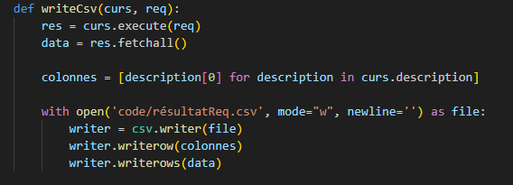

## 1.3 Enrichissement de la base de données (à partir de nouvelles données trouvées sur le web)

*Phase 6: Enrichissement des données*

L’ajout de la table **Criminalité** dans notre base de données a pour but d’analyser les liens entre les phénomènes d’incendies et les contextes sociaux et territoriaux. En particulier, cette table permet de mettre en relation des indicateurs de criminalité par département avec les incendies survenus dans différentes communes. Cela nous permet de voir à travers cette étude s’ il y a une corrélation potentielle entre actes malveillants (comme cause d’incendies) et les taux de criminalité.

**1. Source et importation des données**

Les données ont été récupérées depuis le site officiel **[data.gouv.fr](https://www.data.gouv.fr/)**, garantissant ainsi leur fiabilité. Voici les étapes suivies pour importer ces données :

**1.Téléchargement** : Le jeu de données « Statistiques de la criminalité par département » a été téléchargé au format .csv.

**2.Formatage des champs** : Conversion des champs numériques (comme nombre, taux_pour_mille) en types compatibles. Uniformisation des codes de département en chaînes de caractères (VARCHAR) pour assurer la cohérence avec les autres tables.

**2.Injection des données dans la base**

L’injection de la table *Criminalité* dans la bd s’est faite via le même processus vue précédemment, on a tout simplement ajouter dans la méthode connect() le script SQL:

```sql
CREATE TABLE Criminalite (
  id_criminalité INTEGER PRIMARY KEY AUTOINCREMENT,
  code_departement VARCHAR(15) NOT NULL,
  code_region VARCHAR(15) NOT NULL,
  annee VARCHAR(15) NOT NULL,
  indicateur VARCHAR(25) NOT NULL,
  unite_de_compte VARCHAR(25) NOT NULL,
  nombre VARCHAR(15) NOT NULL,
  taux_pour_mille VARCHAR(15) NOT NULL,
  insee_pop VARCHAR(15) NOT NULL,
  insee_pop_millesime VARCHAR(15) NOT NULL,
  insee_log VARCHAR(15) NOT NULL,
  insee_log_millesime VARCHAR(15) NOT NULL,
  FOREIGN KEY (id_criminalité) REFERENCES Incendies(id_incendie)
);
```

L’insertion des lignes a ensuite été réalisée à l’aide d’un script automatisé lisant chaque ligne du fichier .csv de la même façon que pour les autres tables.

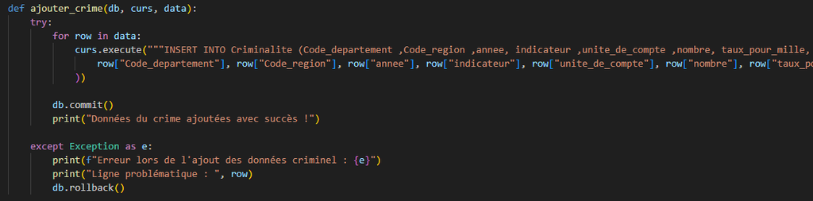

**3. Utilisation et jonction avec les autres tables**

L’intérêt principal de cette table repose sur sa capacité à être mise en relation avec la table **Incendies**. Cela se fait en deux étapes :

**-Étape 1** : Récupération du code_INSEE de la table *Incendies*, qui identifie chaque commune.

**-Étape 2** : Rapprochement avec la table *Criminalité*, en s’appuyant sur le code_departement dérivé du code_INSEE (les deux premiers chiffres du code INSEE correspondent au code du département).

Voici un exemple de requête possible qui permet d’étudier si les incendies malveillants sont plus fréquents dans des zones à forte criminalité.

```sql
SELECT I.commune, I.surface_parcourue_m2, C.indicateur, C.nombre, C.taux_pour_mille
FROM Incendies I
JOIN Criminalite C
ON substr(I.code_INSEE, 1, 2) = C.code_departement
WHERE I.nature_inc_prim = 'Malveillance';
```

Lors de l’étude de cette table nous avons eu quelques problèmes par rapport à la relation des données actuelles avec les nouvelles. Le but était de lier le code départemental stocké dans la table criminalité avec le code insee de la commune (sachant que les deux premier nombre du code insee font référence au code départementale) ce qui fait que nos analyse ne pourront pas se porter sur une commune en particulier mais sur son département. En somme, les données d’un département seront directement liées à sa commune.

# 2 Statistique descriptive

## 2.1 Appropriation des données : Étude descriptive des variables

Dans cette partie, nous allons utiliser la base de données construite précédemment afin de mener une analyse **univariée et bivariée** des variables disponibles. L’objectif est d’explorer la structure des données, de résumer les principales caractéristiques de chaque variable (analyse univariée) et d’examiner les relations potentielles entre deux variables (analyse bivariée). À travers cette analyse, nous chercherons à interpréter les résultats obtenus pour répondre à des problématiques spécifiques.

### 2.1.1 structure des tables

```r
summary(donnees_incendies)
```

```
##   id_incendie      code_INSEE          commune          surface_parcourue_m2
##  Min.   :   1.0   Length:1202        Length:1202        Min.   :  50000
##  1st Qu.: 301.2   Class :character   Class :character   1st Qu.:  69519
##  Median : 601.5   Mode  :character   Mode  :character   Median : 102831
##  Mean   : 601.5                                         Mean   : 179540
##  3rd Qu.: 901.8                                         3rd Qu.: 204950
##  Max.   :1202.0                                         Max.   :1000000
##      annee          mois                jour           heure
##  Min.   :2012   Length:1202        Min.   : 1.00   Min.   : 0.00
##  1st Qu.:2015   Class :character   1st Qu.: 8.00   1st Qu.:12.00
##  Median :2017   Mode  :character   Median :16.00   Median :14.00
##  Mean   :2018                      Mean   :15.64   Mean   :13.89
##  3rd Qu.:2021                      3rd Qu.:23.00   3rd Qu.:16.00
##  Max.   :2022                      Max.   :31.00   Max.   :23.00
##  nature_inc_prim    nature_inc_sec
##  Length:1202        Length:1202
##  Class :character   Class :character
##  Mode  :character   Mode  :character
##
##
##
```

```r
summary(donnees_geo)
```

```
##   code_INSEE           latitude        longitude       altitude_med
##  Length:845         Min.   :-21.31   Min.   :-3.157   Min.   :   0.0
##  Class :character   1st Qu.: 43.13   1st Qu.: 2.389   1st Qu.:  88.0
##  Mode  :character   Median : 43.84   Median : 3.513   Median : 222.0
##                     Mean   : 43.66   Mean   : 4.375   Mean   : 382.2
##                     3rd Qu.: 44.72   3rd Qu.: 5.875   3rd Qu.: 602.0
##                     Max.   : 49.65   Max.   :55.744   Max.   :2100.0
```

```r
summary(donnees_meteo)
```

```
##   code_INSEE            RR_med         NBJRR1_med       NBJRR5_med
##  Length:845         Min.   : 15.50   Min.   : 2.000   Min.   : 1.000
##  Class :character   1st Qu.: 43.10   1st Qu.: 5.000   1st Qu.: 2.500
##  Mode  :character   Median : 57.60   Median : 7.000   Median : 3.000
##                     Mean   : 60.79   Mean   : 7.127   Mean   : 3.549
##                     3rd Qu.: 71.00   3rd Qu.: 9.000   3rd Qu.: 4.000
##                     Max.   :410.10   Max.   :18.000   Max.   :12.000
##   NBJRR10_med       Tmin_med         Tmax_med      Tens_vap_med
##  Min.   :0.500   Min.   :-3.800   Min.   : 2.00   Min.   : 3.30
##  1st Qu.:1.000   1st Qu.: 6.400   1st Qu.:16.20   1st Qu.: 9.60
##  Median :2.000   Median : 7.900   Median :18.50   Median :10.90
##  Mean   :1.868   Mean   : 7.912   Mean   :17.82   Mean   :10.65
##  3rd Qu.:2.000   3rd Qu.: 9.700   3rd Qu.:19.55   3rd Qu.:11.80
##  Max.   :9.000   Max.   :23.900   Max.   :33.65   Max.   :28.00
##  Force_vent_med   Insolation_med Rayonnement_med
##  Min.   : 0.000   Min.   :   0   Min.   :    0
##  1st Qu.: 2.200   1st Qu.:2808   1st Qu.:11304
##  Median : 3.000   Median :3396   Median :12878
##  Mean   : 3.087   Mean   :3048   Mean   :11261
##  3rd Qu.: 3.700   3rd Qu.:4120   3rd Qu.:14634
##  Max.   :10.300   Max.   :5775   Max.   :23126
```

### 2.1.2 Visualisation des 8 premières lines

```r
head(donnees_incendies,8)
```

```
##   id_incendie code_INSEE              commune surface_parcourue_m2 annee mois
## 1           1      43192           Saint-Haon                72000  2012  Feb
## 2           2      15095       Laroquevieille               150000  2012  Feb
## 3           3      15205 Saint-Paul-de-Salers               300000  2012  Mar
## 4           4      15187          Saint-Flour                70000  2012  Mar
## 5           5      15029          Cassaniouze                80000  2012  Mar
## 6           6      15229             Soulages                50000  2012  Mar
## 7           7      12099                Fayet                75000  2012  Mar
## 8           8      12240        Saint-Parthem                75000  2012  Mar
##   jour heure nature_inc_prim nature_inc_sec
## 1   28    13    Involontaire    particulier
## 2   29    13    Involontaire        travaux
## 3    2    13    Involontaire    particulier
## 4    2    13    Involontaire    particulier
## 5    8    11    Involontaire    particulier
## 6   14    19    Accidentelle             NA
## 7    1    16    Involontaire    particulier
## 8    2    14    Involontaire    particulier
```

```r
head(donnees_geo,8)
```

```
##   code_INSEE latitude longitude altitude_med
## 1      43192  44.8548    3.7554         1150
## 2      15095  45.0283    2.5257          940
## 3      15205  45.1374    2.5504          940
## 4      15187  45.0251    3.0730          975
## 5      15029  44.6761    2.3822          439
## 6      15229  45.0897    3.2714          805
## 7      12099  43.8058    2.9703          510
## 8      12240  44.6348    2.2908          260
```

```r
head(donnees_meteo,8)
```

```
##   code_INSEE RR_med NBJRR1_med NBJRR5_med NBJRR10_med Tmin_med Tmax_med
## 1      43192  43.15          7        1.5           1      6.9    16.45
## 2      15095 153.80         13        8.0           5      4.8    15.55
## 3      15205 153.80         13        8.0           5      4.8    15.55
## 4      15187  55.70          9        3.0           2      3.8    13.50
## 5      15029 105.60         11        6.0           3      8.1    18.40
## 6      15229  52.00          8        3.0           1      3.7    13.80
## 7      12099  64.50          9        4.0           2      7.5    14.80
## 8      12240  78.45         10        5.0           3      3.7    15.00
##   Tens_vap_med Force_vent_med Insolation_med Rayonnement_med
## 1         8.10            4.3           3342           12824
## 2         9.40            2.8           3464           12519
## 3         7.60            4.4           3464           12519
## 4         8.70            2.6           3336           12135
## 5         9.65            3.4           3345           11451
## 6         8.30            2.1           3336           12135
## 7        10.60            3.3           3138           12100
## 8         9.65            3.4           3345           11451
```

### 2.1.3 Étude de la dispertion de quelques variables quantitative

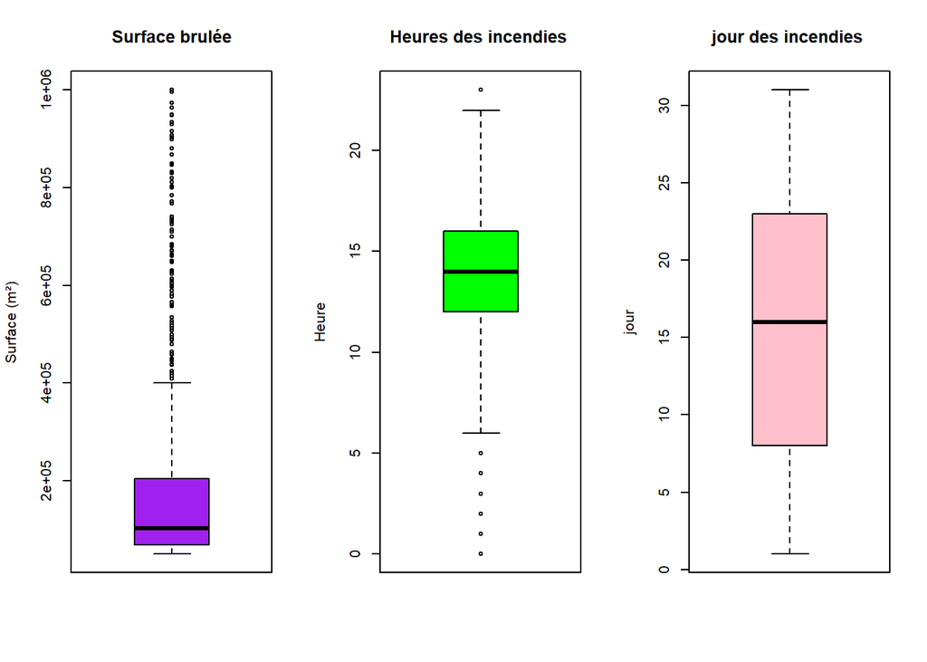

```r
par(mfrow = c(1, 3))

boxplot(donnees_incendies$surface_parcourue_m2,
        main = "Surface brulée",
        ylab = "Surface (m²)",
        col = "purple")

boxplot(donnees_incendies$heure,
        main = "Heures des incendies ",
        ylab = "Heure",
        col = "green")

boxplot(donnees_incendies$jour,
        main="jour des incendies ",
        ylab="jour",
        col="pink")
```

Surface brûlée : La médiane (≈ 102 831 m²) est bien inférieure à la moyenne (≈ 179 540 m²), ce qui indique une distribution asymétrique à droite. Cela signifie que la plupart des incendies couvrent des superficies relativement modestes, tandis que quelques feux exceptionnels, très étendus, tirent la moyenne vers le haut. On est donc en présence de valeurs extrêmes (outliers).

Jour du mois : La médiane se situe à 16, ce qui correspond au milieu du mois. Cette valeur, proche de la moyenne (≈ 15,64), suggère une distribution assez symétrique des incendies tout au long du mois, sans concentration marquée en début ou fin.

Heure de la journée : La médiane (14h) et la moyenne (≈ 13,89) sont très proches, ce qui traduit également une distribution symétrique des départs d’incendies autour du début d’après-midi, sans biais horaire net.

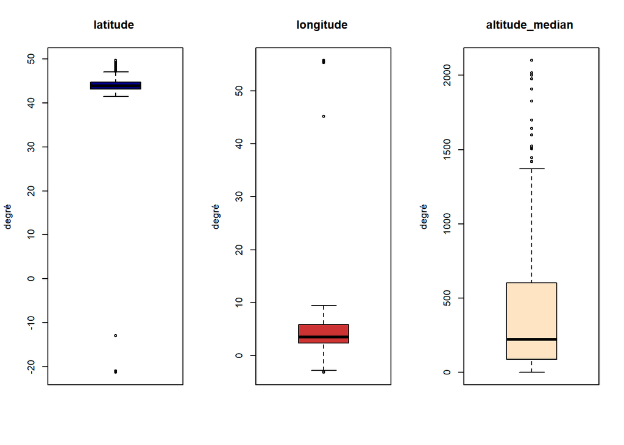

```r
par(mfrow = c(1, 3))

  boxplot(donnees_geo$latitude,
  main="latitude ",
  ylab="degré",
  col="blue4"
  )

boxplot(donnees_geo$longitude,
        main="longitude ",
        ylab="degré",
        col="brown3")

boxplot(donnees_geo$altitude_med,
        main="altitude_median ",
        ylab="degré",
        col="bisque")
```

Les données géographiques indiquent que la grande majorité des incendies se sont produits dans la moitié sud de la France, avec une latitude médiane de 43,84 degrés et une longitude médiane de 3,51 degrés, ce qui correspond aux régions traditionnellement les plus exposées aux feux de forêt comme l’Occitanie, la Provence-Alpes-Côte d’Azur ou encore la Corse. L’altitude médiane des communes touchées est de 222 mètres, ce qui suggère que la plupart des incendies se déclarent dans des zones de basse à moyenne altitude.

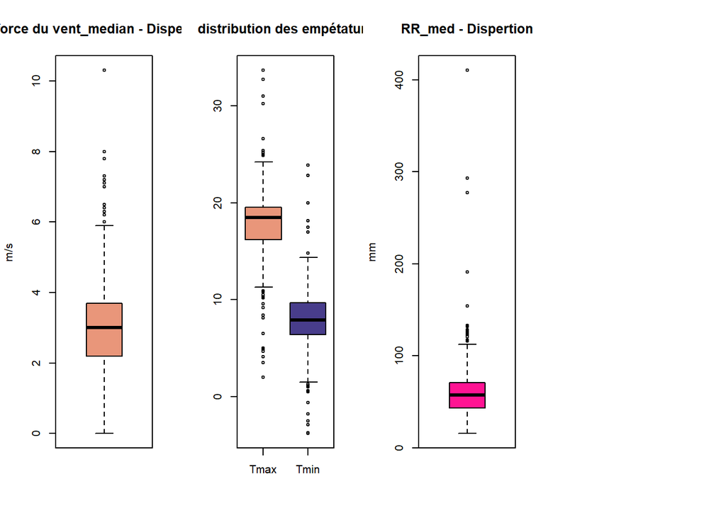

```r
par(mfrow = c(1, 4))

boxplot(donnees_meteo$Force_vent_med,
        main="force du vent_median - Dispertion",
        ylab="m/s",
        col="darksalmon")


boxplot(list(Tmax=donnees_meteo$Tmax_med,Tmin=donnees_meteo$Tmin_med),main="distribution des empétature",col=c("darksalmon","darkslateblue"))


boxplot(donnees_meteo$RR_med,
        main="RR_med - Dispertion",
        ylab="mm",
        col="deeppink")
```

La force moyenne du vent (Force_vent_med) a une médiane de 3 m/s et une moyenne proche (3,09 m/s), ce qui indique une distribution relativement symétrique. La majorité des sites touchés par les incendies connaissent donc des vents modérés.

la médian de la température minimale moyenne (Tmin_med) est de 7,9 °C, tandis que la médian de la température maximale moyenne (Tmax_med) atteint 18,5 °C. Ces valeurs témoignent d’un climat tempéré dans les zones concernées.

Enfin, les précipitations mensuelles moyennes (RR_med) ont une médiane de 57,6 mm et une moyenne légèrement plus élevée (60,8 mm), ce qui reflète une pluviométrie modérée.

```r
var(donnees_incendies$surface_parcourue_m2)
```

```
## [1] 33204180784
```

```r
sd(donnees_incendies$surface_parcourue_m2)
```

```
## [1] 182220.1
```

L’écart-type très élevé par rapport à la médiane (102 831 m²) confirme une forte dispersion des valeurs. Cela signifie qu’il existe des incendies avec des superficies brûlées très variées, dont certaines extrêmement grandes qui tirent la moyenne vers le haut, comme déjà observé

[output not shown]

[output not shown]

L’écart-type modéré (autour de 4 heures) suggère que la majorité des incendies se déclarent dans une plage horaire centrée autour de la médiane (14 h)

```r
var(donnees_meteo$RR_med)
```

```
## [1] 746.4101
```

```r
sd(donnees_meteo$RR_med)
```

```
## [1] 27.32051
```

Les valeurs montrent une dispersion notable autour de la moyenne (~60 mm). Cela reflète une variabilité importante des précipitations selon les zones géographiques : certaines communes reçoivent très peu de pluie, d’autres beaucoup..

### 2.1.4 Distribution des données incndies

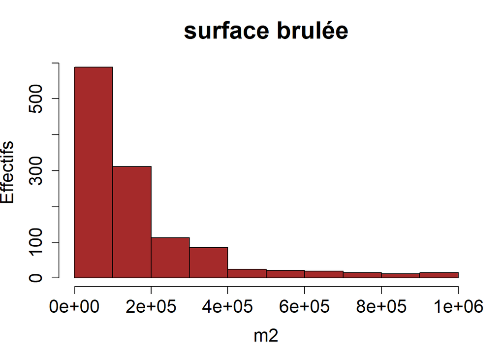

```r
hist(donnees_incendies$surface_parcourue_m2, main  = "surface brulée", xlab = "m2", ylab = "Effectifs", breaks = 10, col = "brown", cex.main = 2, cex.lab = 1.5, cex.axis = 1.5)
```

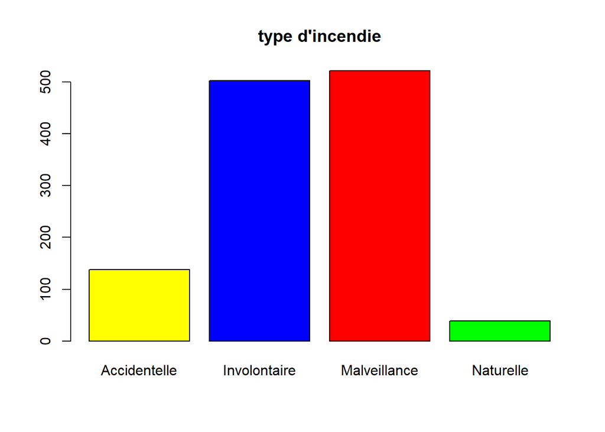

```r
barplot(table(donnees_incendies$nature_inc_prim),main="type d'incendie",col =c("yellow","blue","red","green"))
```

```r
data1=donnees_incendies$annee
data2=as.factor(data1)
table(data2)
```

```
## data2
## 2012 2013 2014 2015 2016 2017 2018 2019 2020 2021 2022
##  122   59   65  107  104  146   42  135  102   79  241
```

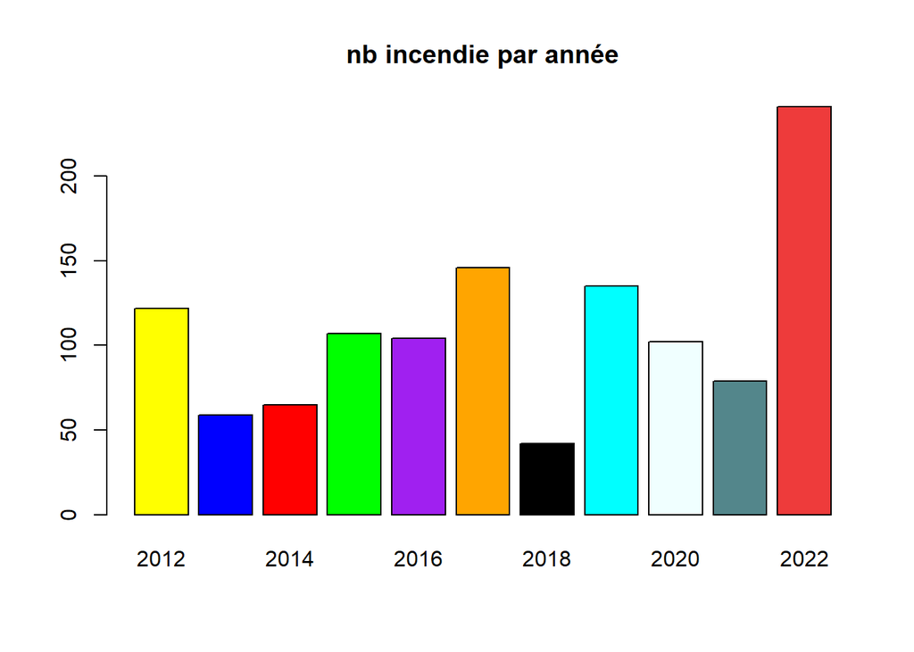

```r
barplot(table(data2),main="nb incendie par année",col =c("yellow","blue","red","green","purple","orange","black","cyan","azure","cadetblue4","brown2"))
```

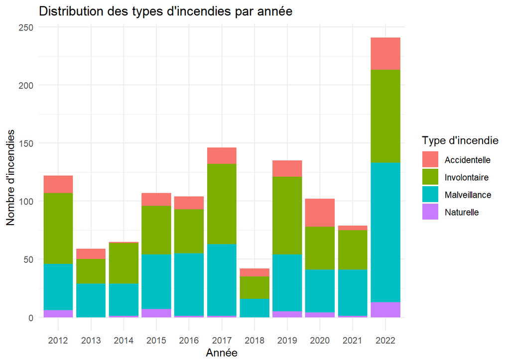

[output not shown]

L’analyse montre que plus de 85 % des incendies sont d’origine humaine. Les incendies malveillants (43,5 %) et involontaires (41,8 %) représentent la majorité des cas

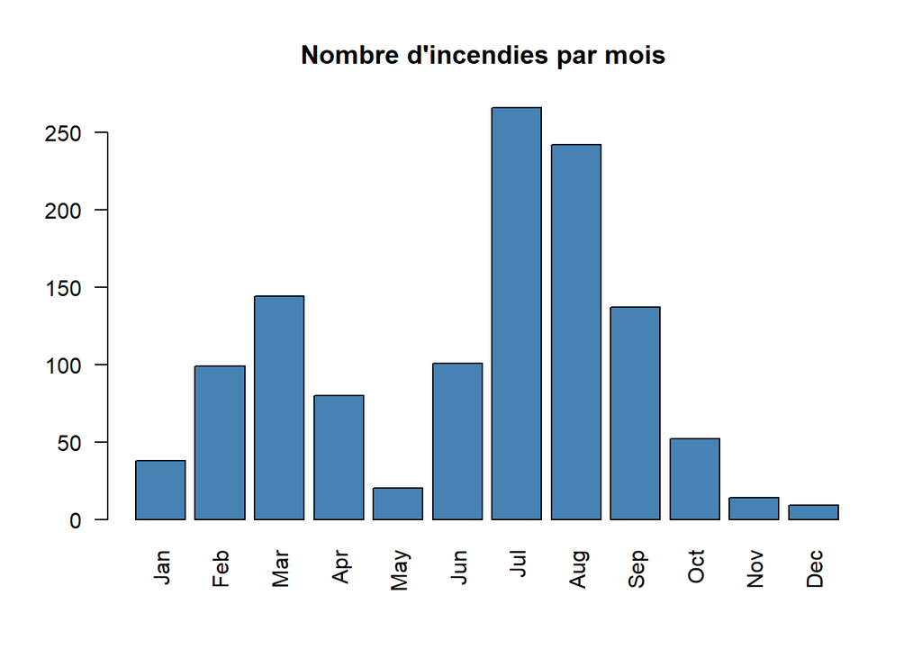

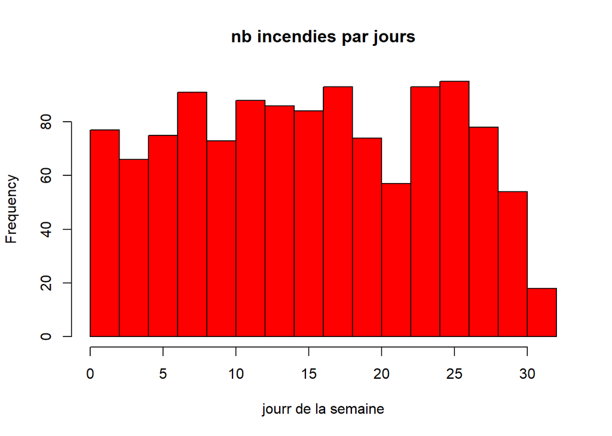

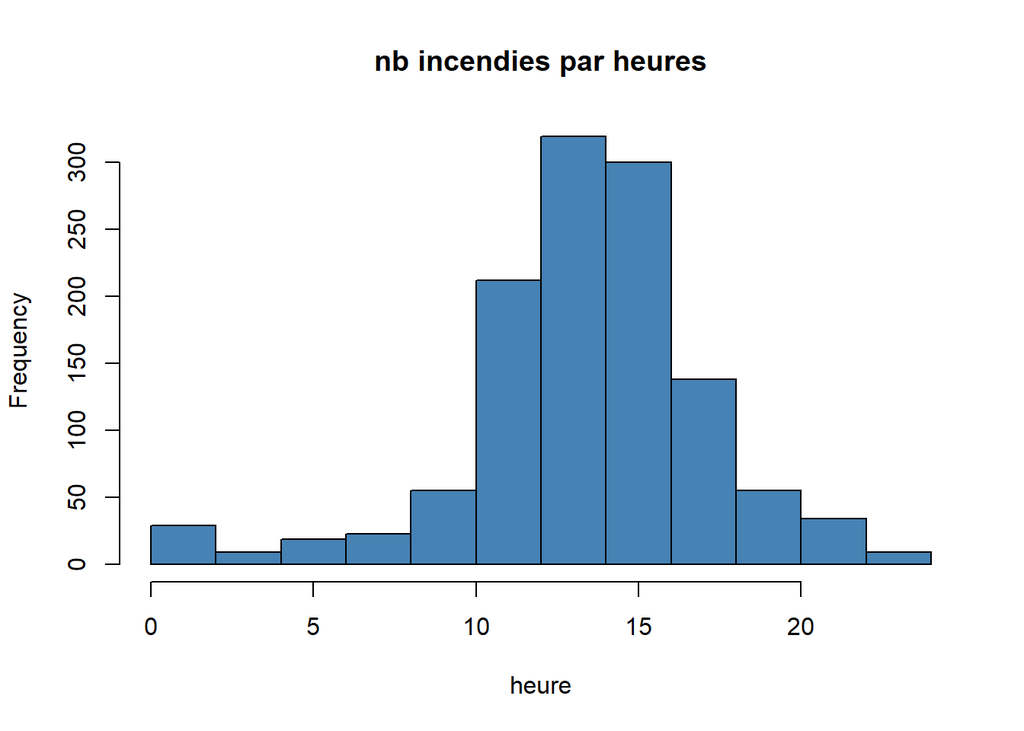

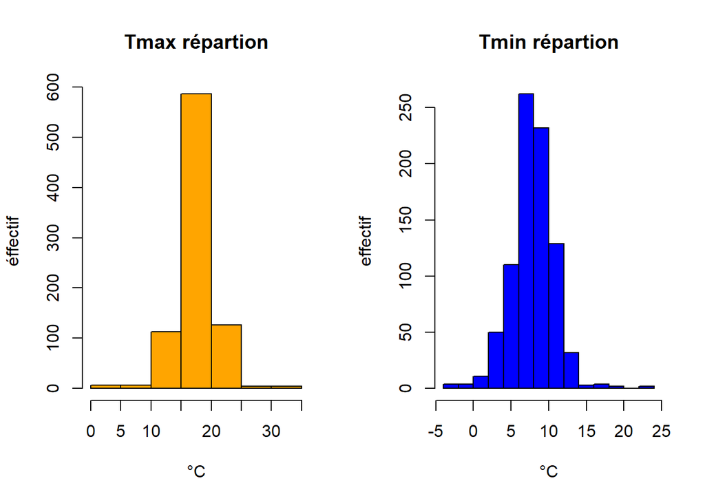

```r
par(mfrow = c(1,2))
hist(donnees_meteo$Tmax_med,main="Tmax répartion",col = "orange",xlab = "°C",ylab = "éffectif" )
hist(donnees_meteo$Tmin_med,main = "Tmin répartion",col="blue",xlab = "°C",ylab = "effectif")
```

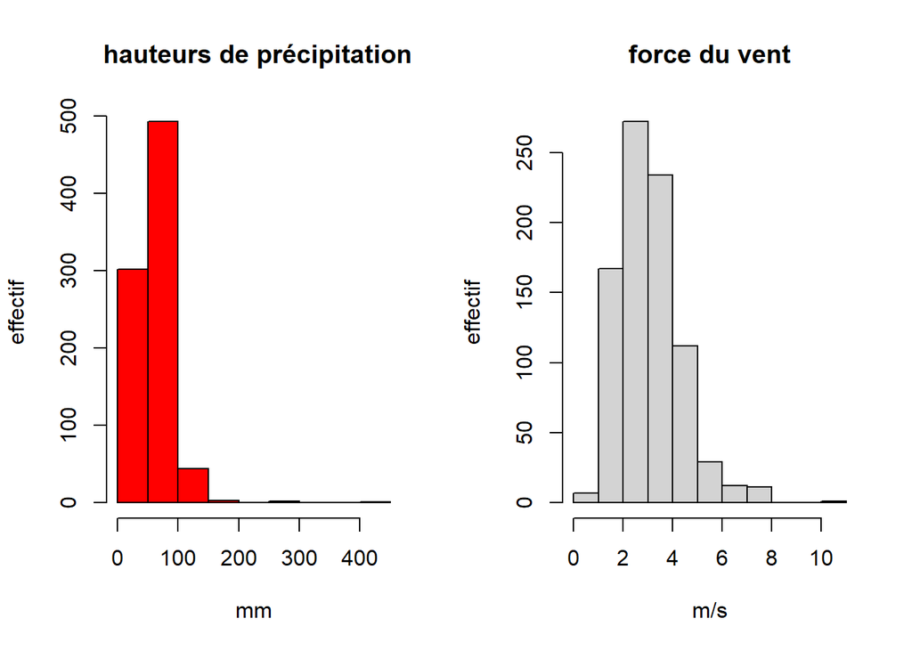

```r
hist(donnees_meteo$RR_med,main=" hauteurs de précipitation",xlab="mm",ylab = "effectif" ,col="red")
hist(donnees_meteo$Force_vent_med,xlab ="m/s" , ylab="effectif",main = "force du vent")
```

```
par(mfrow = c(1,2))
hist(donnees_geo$latitude,main="altitude",col="goldenrod2",xlab="°(degré)",ylab="effectif")
hist(donnees_geo$altitude_med,main="latitude mediane",xlab="°(degré)",ylab="effectif",col="firebrick")
hist(donnees_geo$longitude,main="longitude",xlab="°(degré)",ylab="effectif",col="dimgray")
```

## 2.2 Identification de problématiques statistiques

*PROBLÉMATIQUE 1*: Existe-t-il un lien entre la surface parcourue par les incendies( variable surface_parcourue_m2) et les hauteurs de précipitation médianes (RR_med) de 1950 à 2022 ?

*PROBLÉMATIQUE 2:* Existe -t-il un lien entre le mois(variable mois) et le type d’incendie(nature_inc_prim)?

*PROBLÉMATIQUE 3:* Existe -t-il un lien entre l’heure (variable heure) et la surface parcourue par les incendies( variable surface_parcourue_m2)?

*PROBLÉMATIQUE 4:* Existe -t-il un lien entre la position géoghaphique(variable longitude,latitude) et la surface parcourue par les incendies( variable surface_parcourue_m2)?

*PROBLÉMATIQUE 5:*Existe -t-il un lien entre la force du vent(force_vent_med) et la surface parcourue(surface )

## 2.3 Réponses aux problématiques identifiées

### 2.3.1 Réponse problématique 1

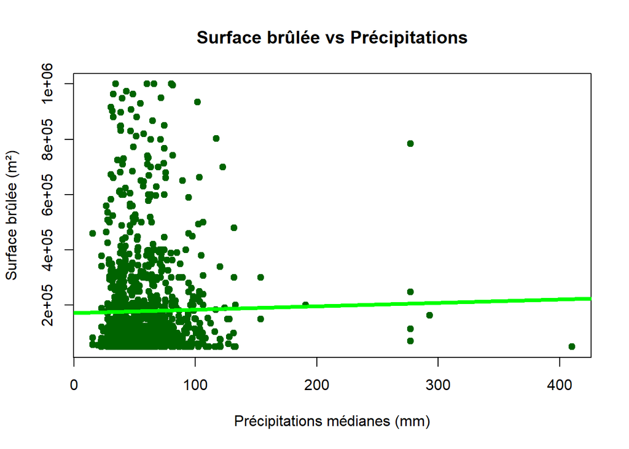

```r
plot(data_biv1$RR_med, data_biv1$surface_parcourue_m2,
     main = "Surface brûlée vs Précipitations",
     xlab = "Précipitations médianes (mm)",
     ylab = "Surface brûlée (m²)",
     col = "darkgreen", pch = 19)

df = data.frame(x =data_biv1$RR_med  , y  = data_biv1$surface_parcourue_m2 )
reglin1 = lm(y ~ x, df)
abline(reglin1, col = "green", lwd = 4)
```

```r
cor(data_biv1$RR_med, data_biv1$surface_parcourue_m2, use = "complete.obs", method = "spearman")
```

```
## [1] 0.02589481
```

### 2.3.2 Réponseproblématique 2

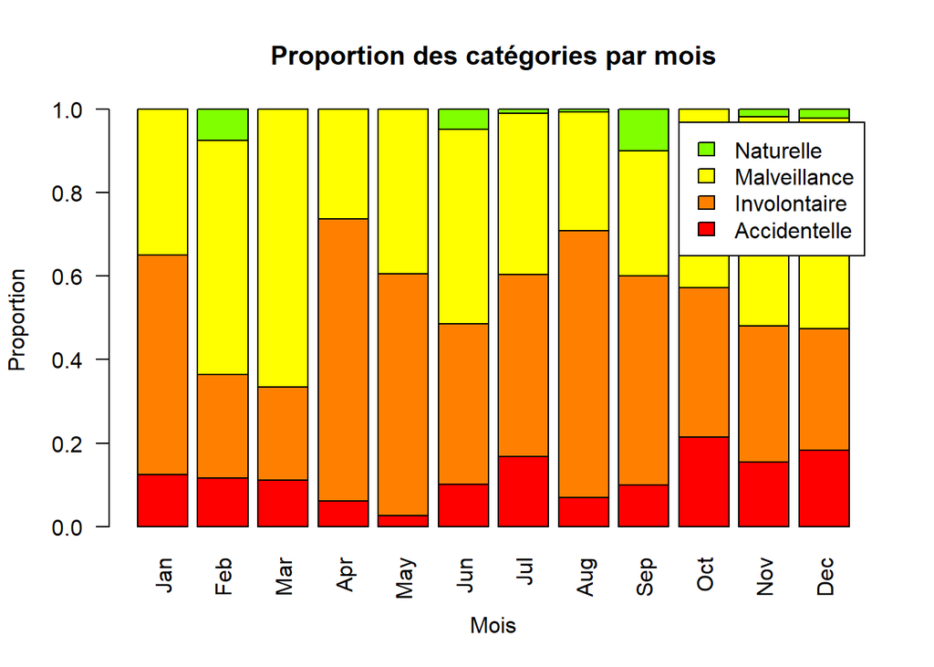

```r
cov_T_M=table(donnees_incendies$mois,donnees_incendies$nature_inc_prim)

months <- c("Jan", "Feb", "Mar", "Apr", "May", "Jun",
            "Jul", "Aug", "Sep", "Oct", "Nov", "Dec")

barplot(t(prop.table(cov_T_M, margin = 1)),
        beside = FALSE,
        legend.text = TRUE,
        names.arg = months,
        col = rainbow(nrow(cov_T_M)),
        main = "Proportion des catégories par mois",
        xlab = "Mois",
        ylab = "Proportion",las=2)
```

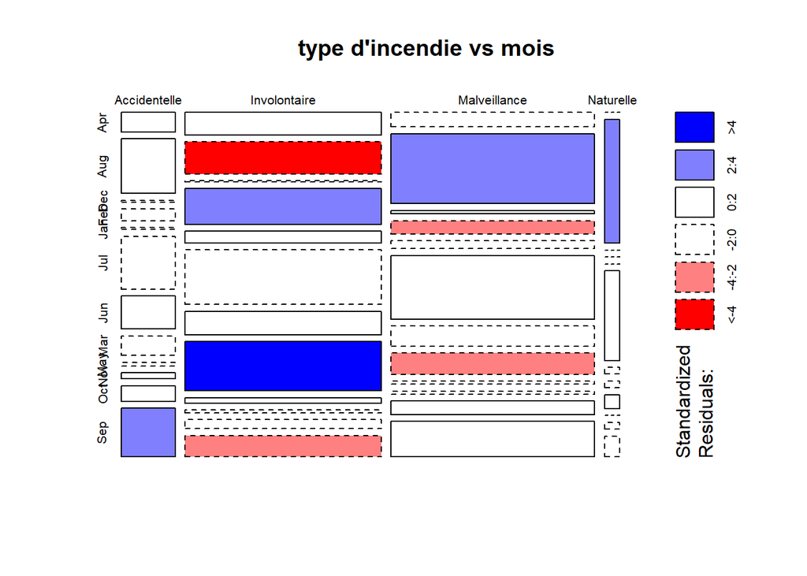

```r
mosaicplot(t(cov_T_M), main = "type d'incendie vs mois", shade = TRUE)
```

```r
cramer.v = function(TABLECONT){
  khi2 = chisq.test(TABLECONT)$statistic
  ntot = sum(TABLECONT)
  L = nrow(TABLECONT)
  C = ncol(TABLECONT)
  V_C = sqrt(khi2 / (ntot * (min(L, C) - 1)))
  return(V_C)
}
v_cramer=cramer.v(cov_T_M)
v_cramer
```

```
## X-squared
## 0.1979527
```

*Interprétation : Le V de Cramér entre les variables type d’incendie et mois est égal à 0.1979527.Cela indique une association très faible entre les deux variables.Autrement dit, le type d’incendie est faiblement dépendant du mois, mais il existe tout de même une légère variation de répartition selon les périodes de l’année.*

### 2.3.3 Réponse problématique 3

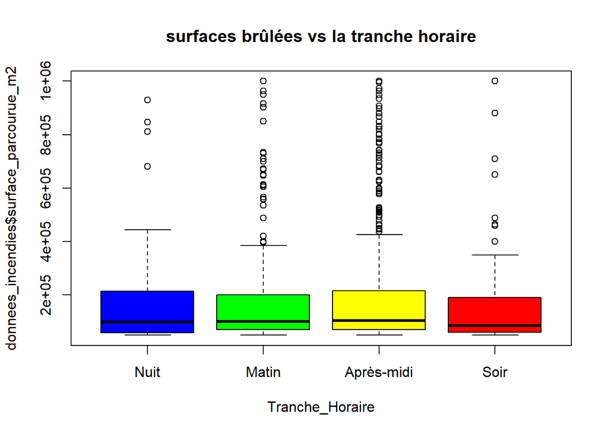

```r
donnees_incendies$Tranche_Horaire <- cut(donnees_incendies$heure, breaks=c(0, 6, 12, 18, 24),
                                    labels=c("Nuit", "Matin", "Après-midi", "Soir"))
boxplot(donnees_incendies$surface_parcourue_m2 ~ Tranche_Horaire, data=donnees_incendies,
        main="surfaces brûlées vs la tranche horaire",
        col=c("blue", "green", "yellow", "red"))
```

```r
cor(donnees_incendies$heure, donnees_incendies$surface_parcourue_m2 , use="complete.obs")
```

```
## [1] -0.01342712
```

*Interprétation: La corrélation linéaire entre la surface brûlée et l’heure de l’incendie est de -0.01342712.Cela signifie qu’il n’existe quasiment aucun lien linéaire entre ces deux variables.Autrement dit, l’heure à laquelle un incendie se déclenche n’influence pas de manière significative la surface brûlée.*

### 2.3.4 Réponse problématique 4

```r
cor(data_biv2$latitude, data_biv2$surface_parcourue_m2, use = "complete.obs")
```

```
## [1] 0.01860566
```

```r
cor(data_biv2$longitude, data_biv2$surface_parcourue_m2, use = "complete.obs")
```

```
## [1] -0.007044994
```

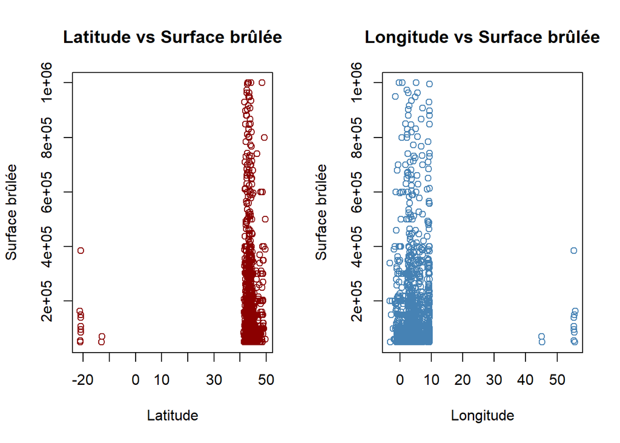

```r
par(mfrow = c(1, 2))
plot(data_biv2$latitude, data_biv2$surface_parcourue_m2,
     main = "Latitude vs Surface brûlée", xlab = "Latitude", ylab = "Surface brûlée", col = "darkred")

plot(data_biv2$longitude, data_biv2$surface_parcourue_m2,
     main = "Longitude vs Surface brûlée", xlab = "Longitude", ylab = "Surface brûlée", col = "steelblue")
```

*Interprétation :La corrélation linéaire entre la latitude et la surface brûlée est de : 0.0186 et celle entre la longitude et la surface brûlée est de : –0.0070 ;Ces deux coefficients de corrélation sont très proches de zéro, ce qui indique l’absence de relation linéaire significative entre la position géographique (latitude ou longitude) et la surface brûlée(surface_parcourue_m2).*

***Remarque : L’absence de corrélation linéaire n’exclut pas la possibilité d’un lien non linéaire**

### 2.3.5 Réponse Problématique 5

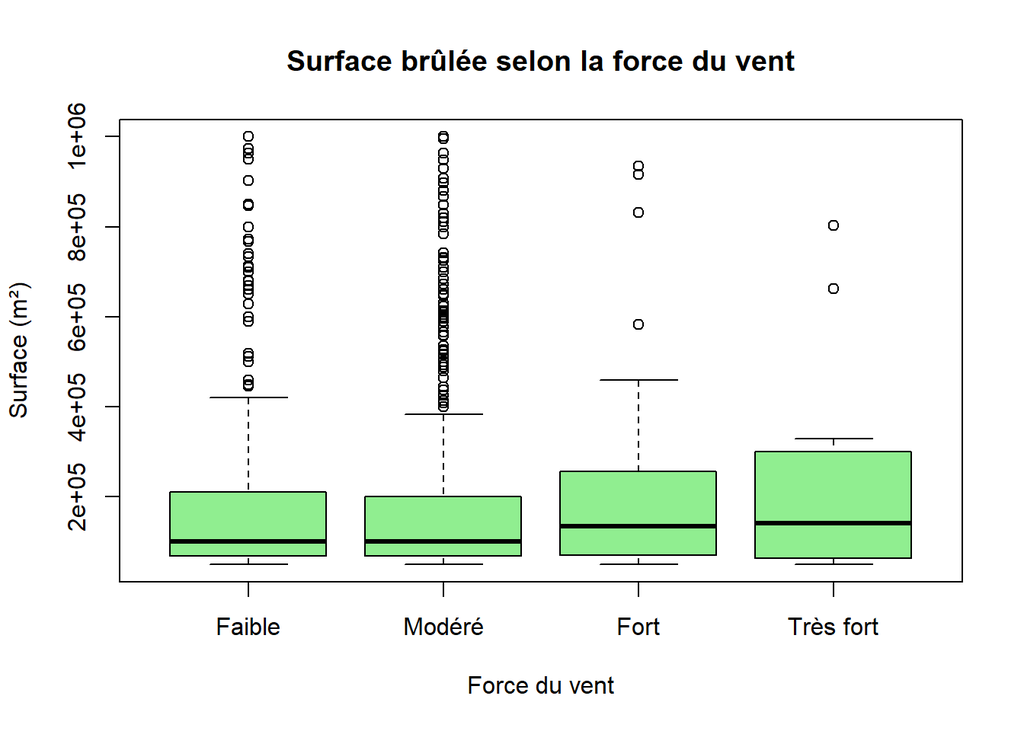

```r
data_biv1$vent_cat <- cut(data_biv1$Force_vent_med, breaks = 4,
                          labels = c("Faible", "Modéré", "Fort", "Très fort"))
boxplot(surface_parcourue_m2 ~ vent_cat, data = data_biv1,
        col = "lightgreen", main = "Surface brûlée selon la force du vent",
        xlab = "Force du vent", ylab = "Surface (m²)")
```

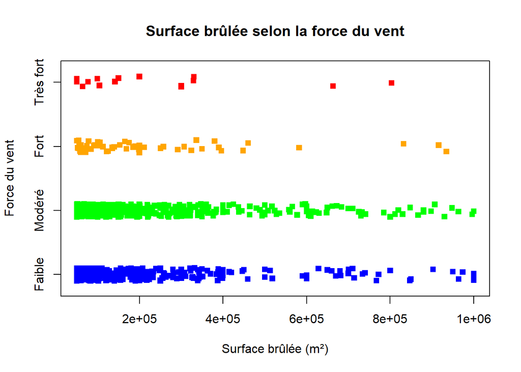

```r
stripchart(surface_parcourue_m2 ~ vent_cat,
           data = data_biv1,
           method = "jitter",
           vertical = FALSE,
           pch = 15,
           col = c("blue", "green", "orange", "red"),
           main = "Surface brûlée selon la force du vent",
           xlab = "Surface brûlée (m²)",
           ylab = "Force du vent")
```

```r
res_lm_vent <- lm(surface_parcourue_m2 ~ Force_vent_med, data = data_biv1)
cor_vent_surface <- sqrt(summary(res_lm_vent)$r.squared)
cor_vent_surface
```

```
## [1] 0.03137438
```

*Interprétation: La corrélation linéaire entre la force moyenne du vent (Force_vent_med) et la surface brûlée (surface_parcourue_m2) est de 0.03137438 , Cette valeur est très proche de zéro, ce qui signifie qu’il n’existe quasiment aucun lien linéaire entre la force du vent et la surface brûlée.Autrement dit, la force du vent mesurée n’a pas d’influence significative (au sens linéaire) sur l’étendue des surfaces brûlées dans ce jeu de données.*